# Parameterized report COVID-19

Met de data van het European Center for Disease Control (ECDC) wordt een parameterized rapport gemaakt van COVID-19 cases. Het rapport wordt gemaakt op basis van de drie parameters:

- Het land waarop het rapport van toepassing is
- Het jaar waarop de gerapporteerde data betrekking heeft
- De periode in maanden waarop het rapport van toepassing is

Hiervoor wordt er gebruik gemaakt van ECDC COVID-19 gegevens: [ECDC data](https://www.ecdc.europa.eu/en/publications-data/data-daily-new-cases-covid-19-eueea-country).

## Importeren en inspecteren

| dateRep | day | month | year | cases | deaths | countriesAndTerritories | geoId | countryterritoryCode | popData2020 | continentExp |
| --- | --- | --- | --- | --- | --- | --- | --- | --- | --- | --- |
| 23/10/2022 | 23 | 10 | 2022 | 3557 | 0 | Austria | AT | AUT | 8901064 | Europe |
| 22/10/2022 | 22 | 10 | 2022 | 5494 | 4 | Austria | AT | AUT | 8901064 | Europe |
| 21/10/2022 | 21 | 10 | 2022 | 7776 | 4 | Austria | AT | AUT | 8901064 | Europe |
| 20/10/2022 | 20 | 10 | 2022 | 8221 | 6 | Austria | AT | AUT | 8901064 | Europe |
| 19/10/2022 | 19 | 10 | 2022 | 10007 | 8 | Austria | AT | AUT | 8901064 | Europe |
| 18/10/2022 | 18 | 10 | 2022 | 13204 | 7 | Austria | AT | AUT | 8901064 | Europe |
| 17/10/2022 | 17 | 10 | 2022 | 9964 | 8 | Austria | AT | AUT | 8901064 | Europe |
| 16/10/2022 | 16 | 10 | 2022 | 6606 | 12 | Austria | AT | AUT | 8901064 | Europe |
| 15/10/2022 | 15 | 10 | 2022 | 8818 | 6 | Austria | AT | AUT | 8901064 | Europe |
| 14/10/2022 | 14 | 10 | 2022 | 11751 | 10 | Austria | AT | AUT | 8901064 | Europe |

[output cut: 28719 more lines]

## Lijngrafiek Nederland, Frankrijk en Spanje

Met de ECDC COVID-19 gegevens is er een visuele weergave van COVID-19 cases en deaths in geselecteerde landen en jaargetallen. De grafieken tonen het aantal cases en deaths per datum. Door gebruik te maken van parametrisatie in de R-code met `params$`, kan dit rapport eenvoudig aangepast worden aan specifieke interesses zonder dat je de onderliggende code hoeft te wijzigen.

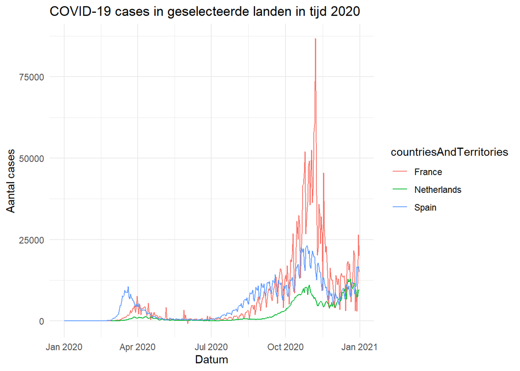

Lijngrafiek van COVID-19 data, waarbij de datum in jaar en maand op de x-as staat, de aantal cases op de y-as. Verschillende kleuren vertegenwoordigen geselecteerde landen Nederland, Frankrijk en Spanje.

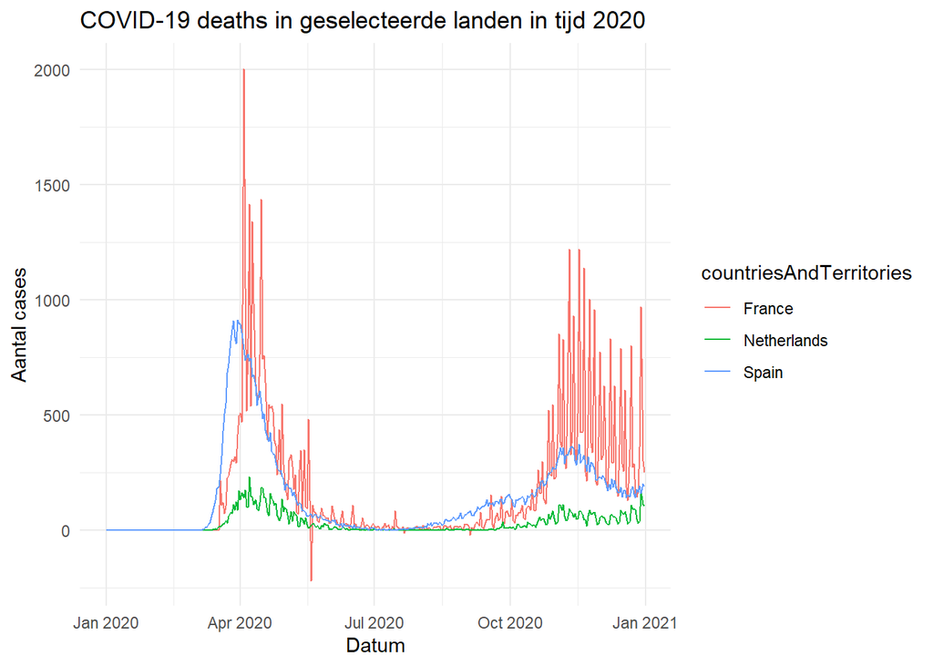

## Lijngrafiek Roemenië, Noorwegen en Italië

Om te controleren of de parametrisatie correct functioneert, kan je de waarden in de parameterlijst aanpassen. In dit voorbeeld worden de landen Roemenië, Noorwegen en Italië gebruikt en het jaar 2021.

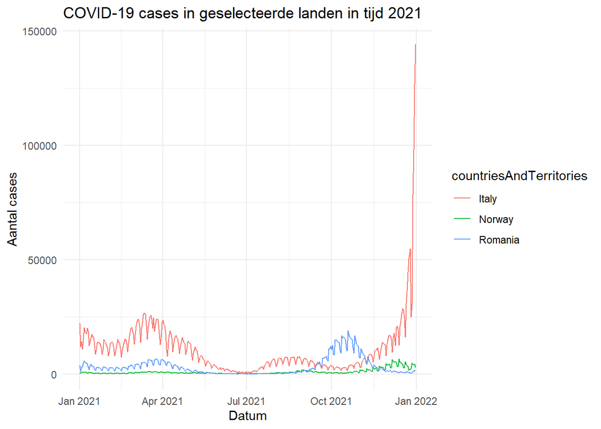

Lijngrafiek van COVID-19 data, waarbij de datum in jaar en maand op de x-as staat, de aantal cases op de y-as. Verschillende kleuren vertegenwoordigen geselecteerde landen Roemenië, Noorwegen en Italië.

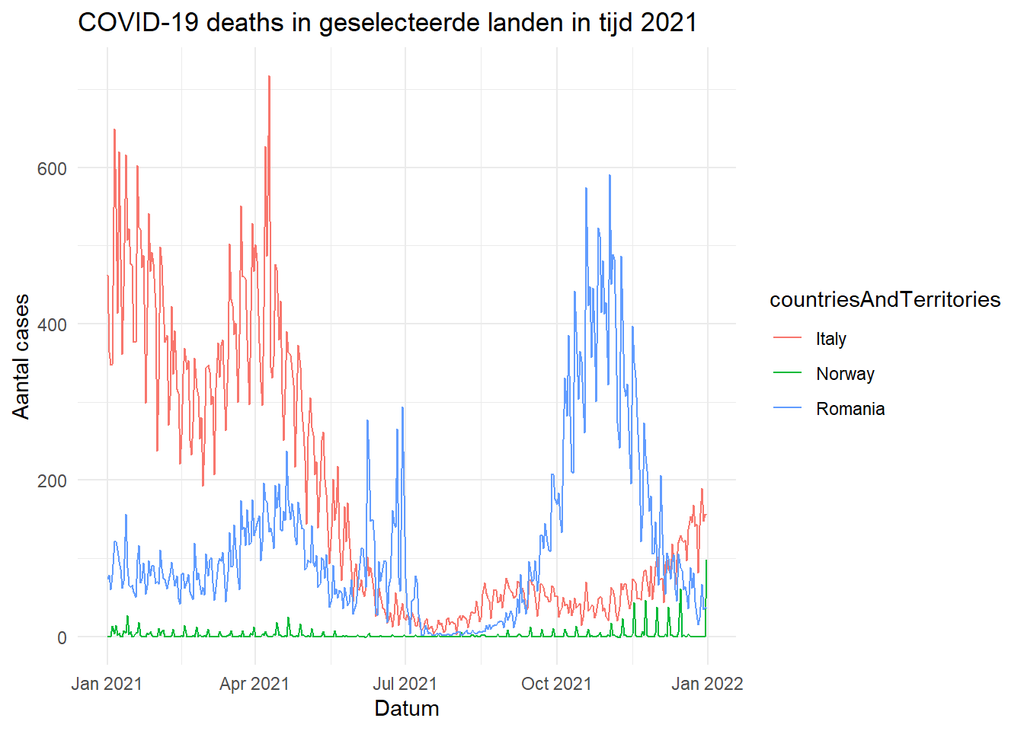